# ANALYSIS OF PROSPER LOAN DATA by ABHISHEK CHHIBBER

## About the Project

#### In this project, I have analysed loan payments and defaults of a dataset,

#### containing details of 113,937 loans.

## Libraries Used:

- ggplot2
- dplyr
- knitr

# data.frame columns:

```
## 'data.frame':    113937 obs. of  81 variables:
##  $ ListingKey                         : Factor w/ 113066 levels "00003546482094282EF90E5",..: 7180 7193 6647 6669 6686 6689 6699 6706 6687 6687 ...
##  $ ListingNumber                      : int  193129 1209647 81716 658116 909464 1074836 750899 768193 1023355 1023355 ...
##  $ ListingCreationDate                : Factor w/ 113064 levels "2005-11-09 20:44:28.847000000",..: 14184 111894 6429 64760 85967 100310 72556 74019 97834 97834 ...
##  $ CreditGrade                        : Factor w/ 9 levels "","A","AA","B",..: 5 1 8 1 1 1 1 1 1 1 ...
##  $ Term                               : int  36 36 36 36 36 60 36 36 36 36 ...
##  $ LoanStatus                         : Factor w/ 12 levels "Cancelled","Chargedoff",..: 3 4 3 4 4 4 4 4 4 4 ...
##  $ ClosedDate                         : Factor w/ 2803 levels "","2005-11-25 00:00:00",..: 1138 1 1263 1 1 1 1 1 1 1 ...
##  $ BorrowerAPR                        : num  0.165 0.12 0.283 0.125 0.246 ...
##  $ BorrowerRate                       : num  0.158 0.092 0.275 0.0974 0.2085 ...
##  $ LenderYield                        : num  0.138 0.082 0.24 0.0874 0.1985 ...
##  $ EstimatedEffectiveYield            : num  NA 0.0796 NA 0.0849 0.1832 ...
##  $ EstimatedLoss                      : num  NA 0.0249 NA 0.0249 0.0925 ...
##  $ EstimatedReturn                    : num  NA 0.0547 NA 0.06 0.0907 ...
##  $ ProsperRating..numeric.            : int  NA 6 NA 6 3 5 2 4 7 7 ...
```

[output cut: 67 more lines]

# Summary of few variables:

### Borrowers’ rate of interest

```
##    Min. 1st Qu.  Median    Mean 3rd Qu.    Max.
##  0.0000  0.1340  0.1840  0.1928  0.2500  0.4975
```

### Borrowers’ income range

```
##             $0      $1-24,999      $100,000+ $25,000-49,999 $50,000-74,999
##            621           7274          17337          32192          31050
## $75,000-99,999  Not displayed   Not employed
##          16916           7741            806
```

### Amount of loan

```
##    Min. 1st Qu.  Median    Mean 3rd Qu.    Max.
##    1000    4000    6500    8337   12000   35000
```

# Univariate Plots Section

#### Figure 1: Loans by terms

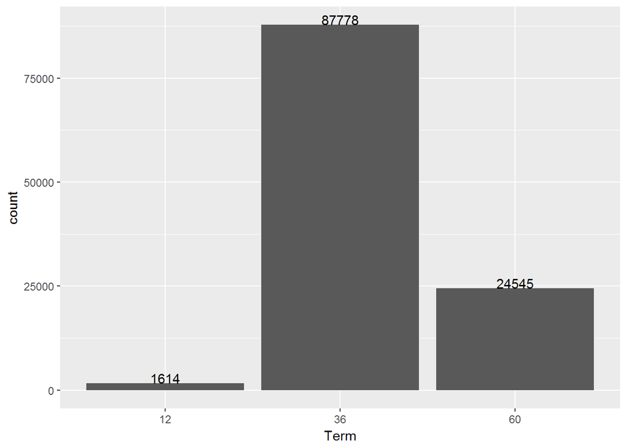

> Majority of the loans are of 36-month term, followed by those with 60-month term.

#### Figure 2: Loans by Loan Status

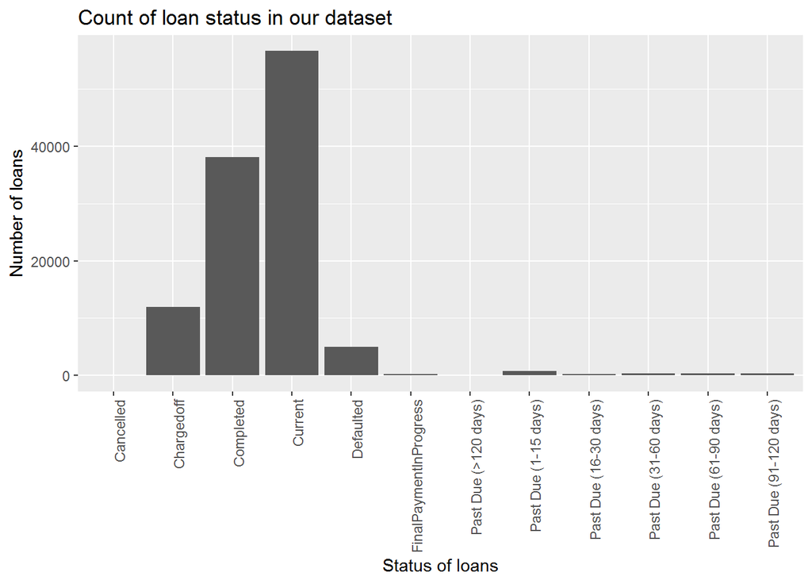

> Majority of the loans are either current or completed

#### Figure 3: Loans by Borrower’s Occupation (Top-10)

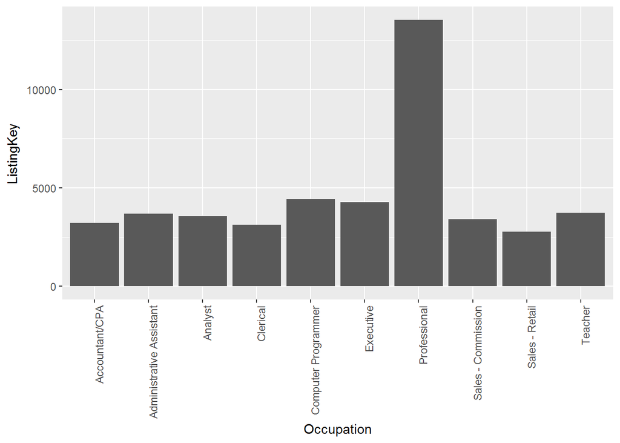

> Professionals, Computer Programmers, and Executives are the major loan takers.

#### Figure 4: Loans by Borrower’s employment status

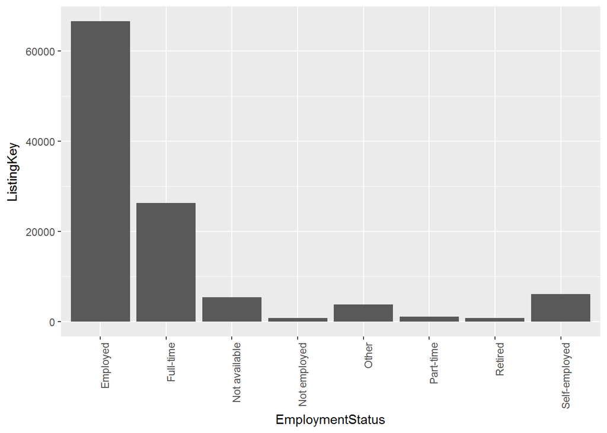

> Majority of the loan takers are employed, or have full-time employment

### Checking if the borrower is home owner

#### Figure 5: % of loan takers as home owners

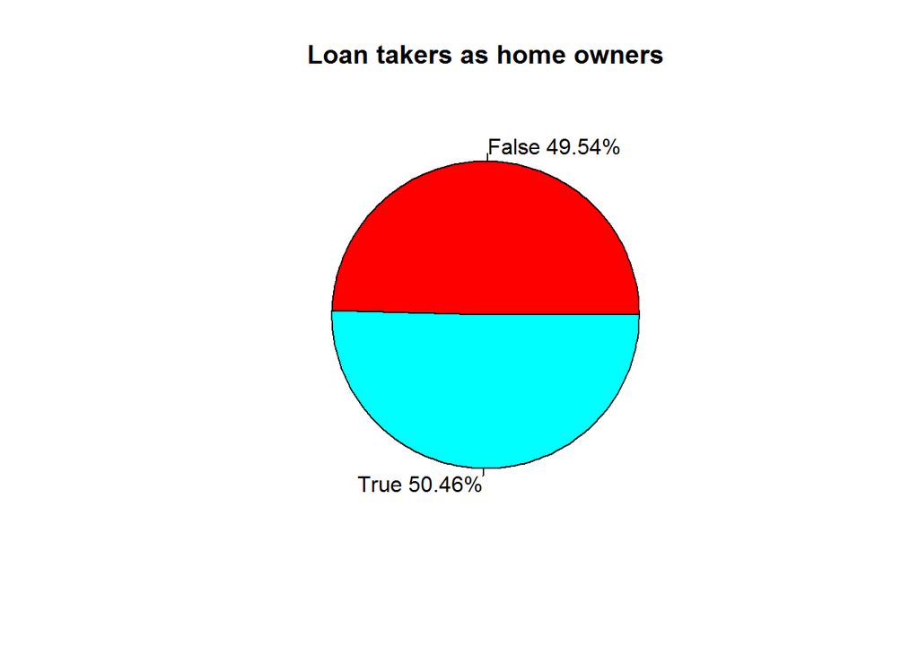

> Ratio of home owners to non-home owners is almost equal

### Number of applicants having prior loans

#### Figure 6: % of Borrowers having prior loans

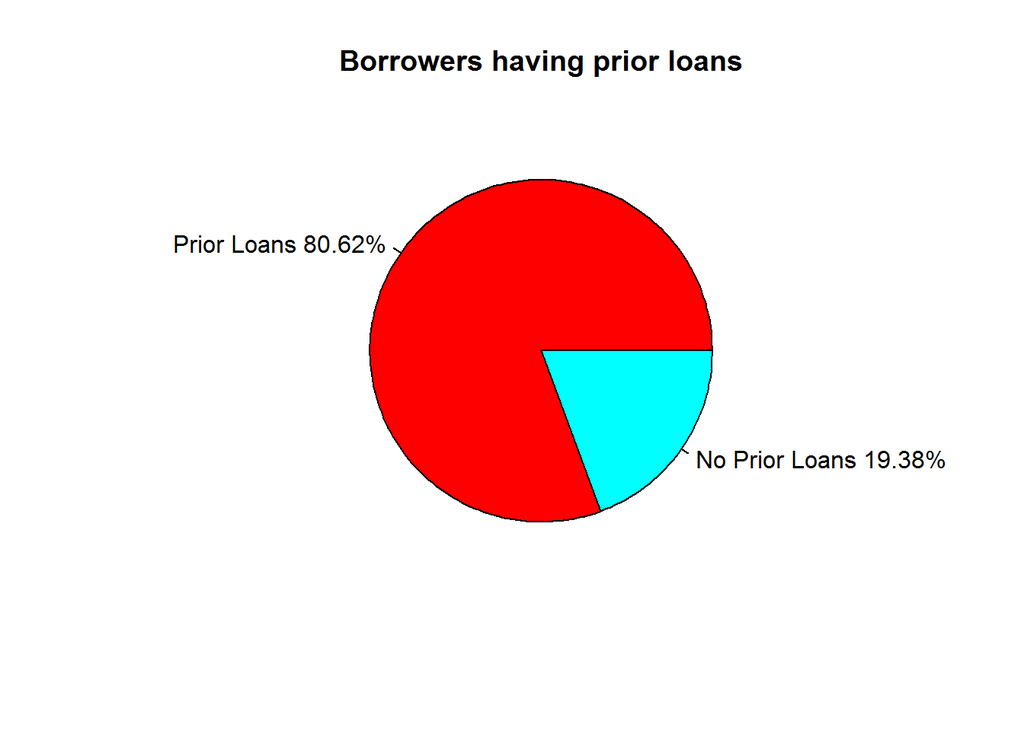

> 80.62% of the borrowers had prior loans

#### Figure 7: Monthly loan payments by borrowers

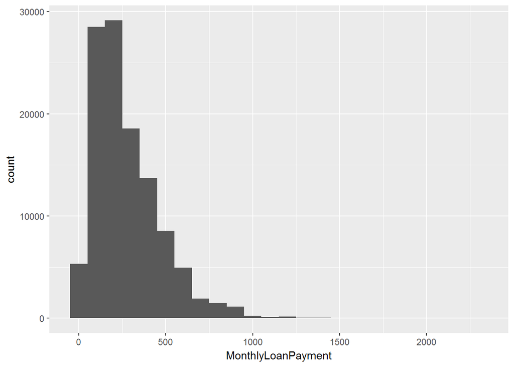

#### Figure 8: Plot after removing outliers

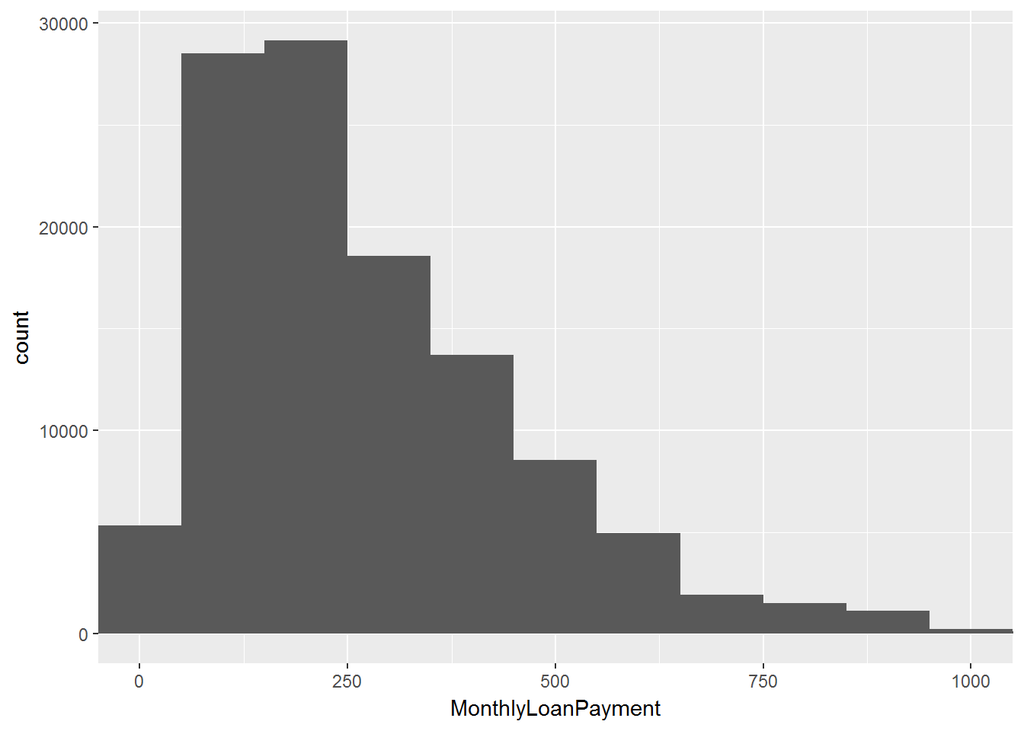

# Univariate Analysis

### What is the structure of your dataset?

The dataset contains details on 113,937 loans, across 81 variables. The variables are numeric, string, as well as factors.

The dataset is not cleaned, and had to be wrangled upon, during analysis.

### What is/are the main feature(s) of interest in your dataset?

The main features of interest are the different variables, which directly or indirect play role in loan taking and paying capacity of a borrower. I’d like to check the relationship between different variables, as well as between variables and loan payments and defaults.

### What other features in the dataset do you think will help support your investigation into your feature(s) of interest?

Some of the variables were processed and simplified into new variables, to use them as ordered factors. E.g. There is a variable of stated monthly income that provides discrete income of all the borrowers, and another variable of income range, which provides bins of income, to be used as a factor.

### Did you create any new variables from existing variables in the dataset?

Besides the 81 already existing variable, ‘OnTimePaymentsDefaults’. This is subtraction of ‘OnTimeProsperPayments’ from ‘TotalProsperPaymentsBilled’, and sepicts the prosper payments billed, and not paid. This variable was created to find the loans/borrowers which had defaulted, and compare them on several other variables - in multivariate analysis.

### Of the features you investigated, were there any unusual distributions? Did you perform any operations on the data to tidy, adjust, or change the form of the data? If so, why did you do this?

The dataset was not tidy, and I had to do some data wrangling to use it. Though I did not change the data to log etc, I worked on creating ordered factors, cleaning out Null and NA data, and assigning new values through conditions.

# Bivariate Plots Section

### Checking if the income stated by borrower is correct

Following chart studies the relationship between ‘Income Range’ and ‘Stated Monthly Income’ to check if data in both the columns is matching

#### Figure 9: Stated monthly income of borrowers, by income range

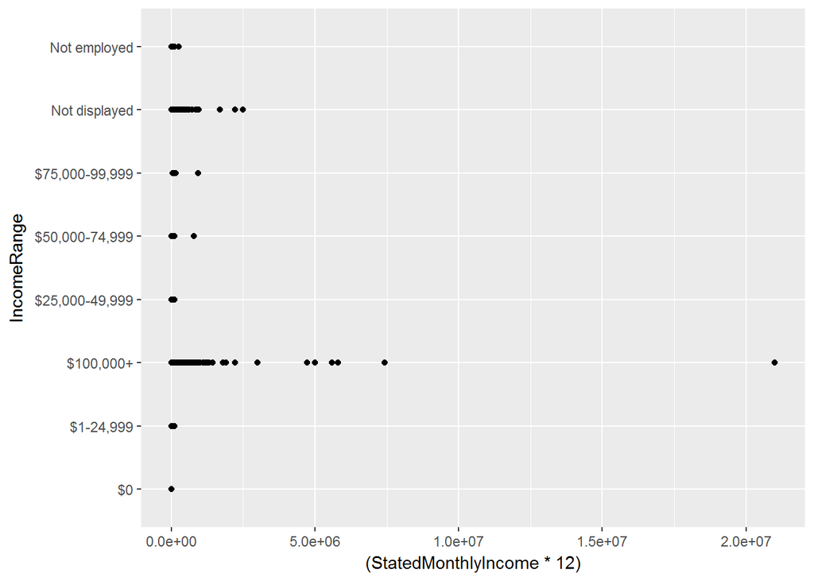

> There are very few outliers, when comparing income range and stated monthly income.

Scatter plot of monthly income and monthly loan payments

#### Figure 10: Relationship between stated monthly income and monthly loan payment (1)

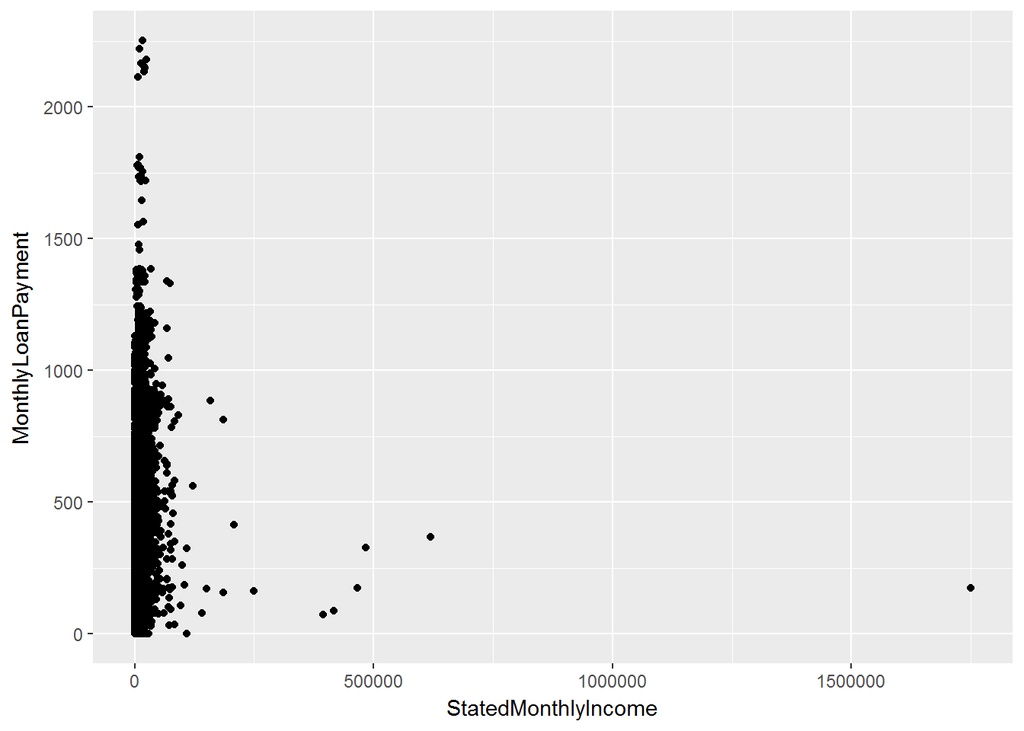

Scatter plot with outliers removed and alpha decreased to get the following plot:

#### Figure 11: Relationship between stated monthly income and monthly loan payment (2)

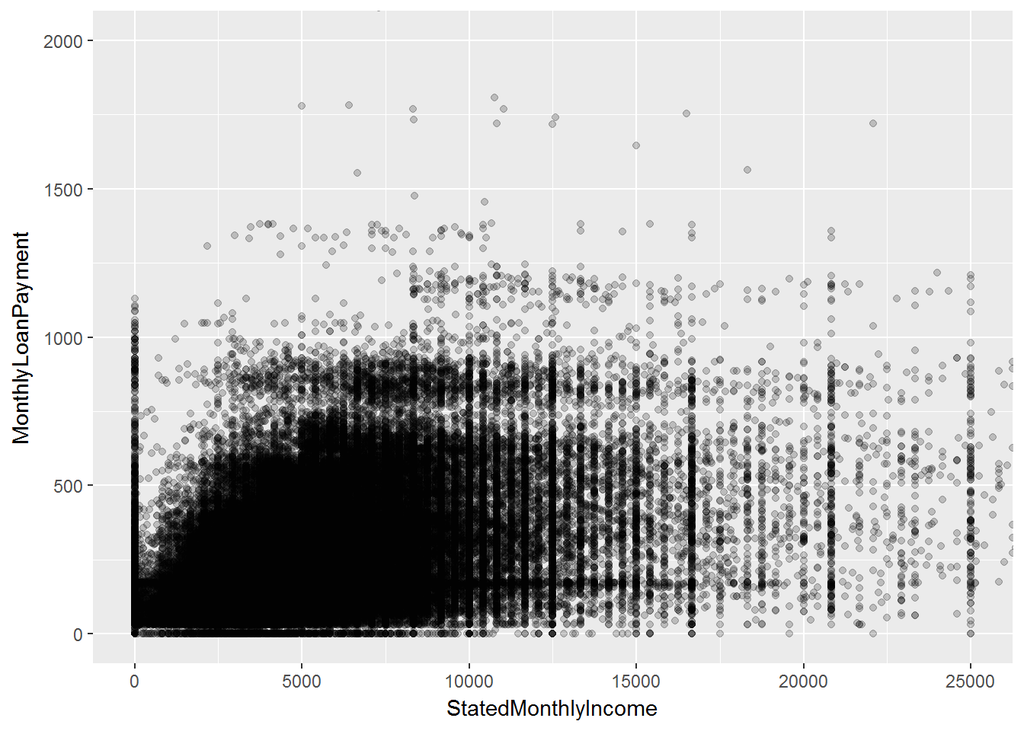

> Majority of borrowers with monthly income of upto $10,000 pay monthly loan payment of upto $1,000.

Individual debt to income ratio for all the income ranges

#### Figure 12: Relationship between Debt to Income Ratio and Income Range (1)

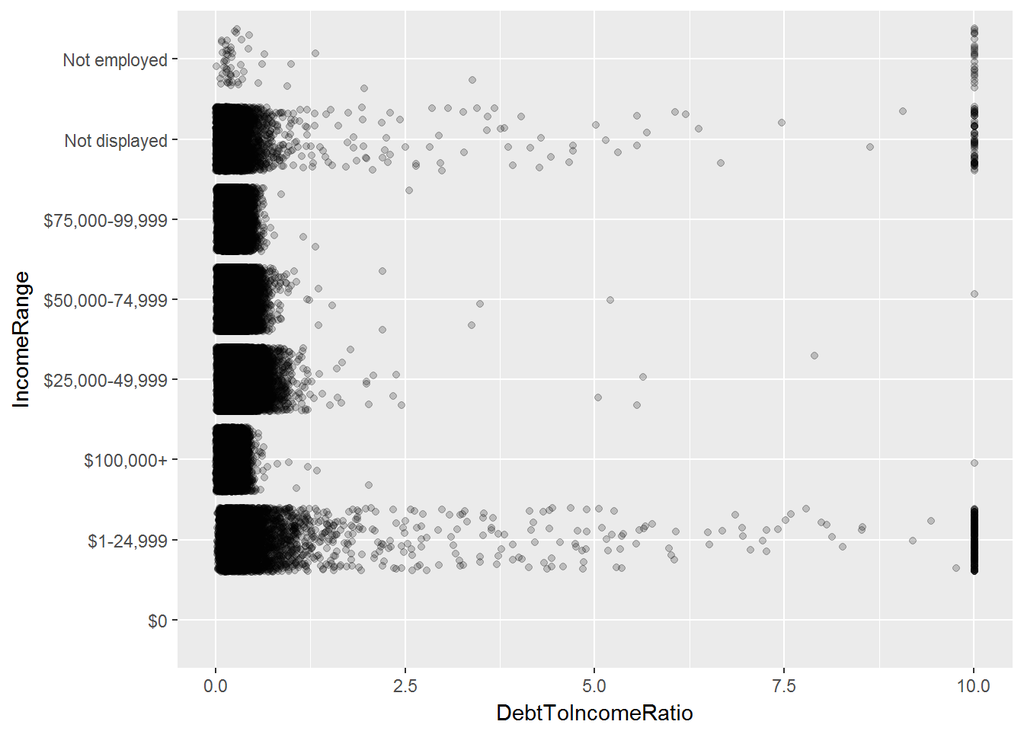

Consistancy of data checked further through a box plot

#### Figure 13: Relationship between Debt to Income Ratio and Income Range (2)

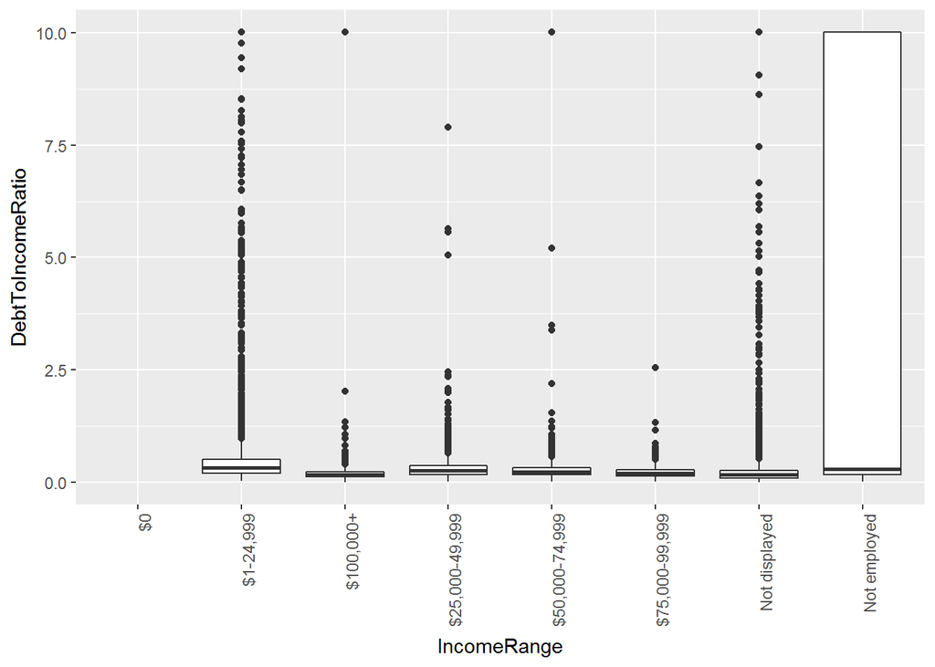

> Some of the ranges have high whiskers, which shows a lot of data points above upper quartile.

Therefore, rather than mean, median debt to income ratio for all income ranges was plotted

#### Figure 14: Relationship between median Debt to Income Ratio and Income Range

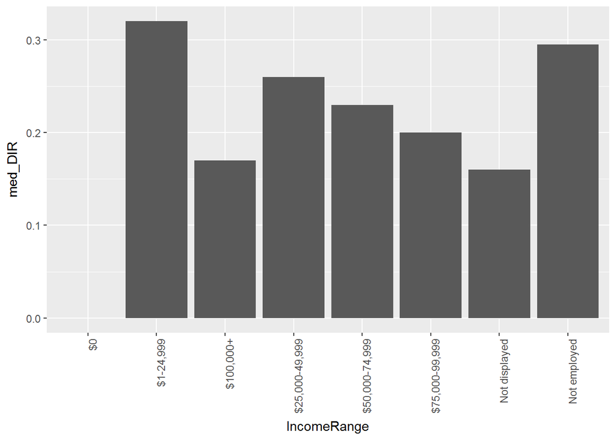

> The median debt to income ratio is higher for borrowers who are unemployed, or have income less than $25,000

### Borrower payment success rate

First, proportion of ontime payments that borrowers made, out of the prosper payments billed was analyzed

#### Figure 15: % of loan payments made and remaining

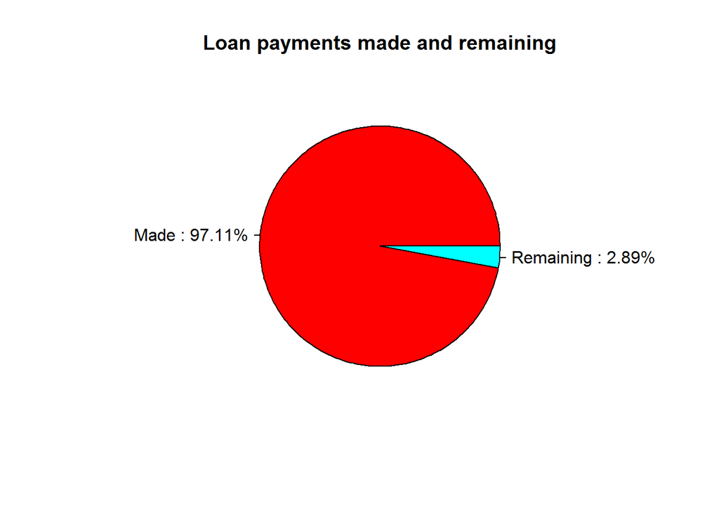

Loan payments made and defaulted were analyzed, and categorized by income range.

#### Figure 16: Loan defaulters and non-defaulters by income range

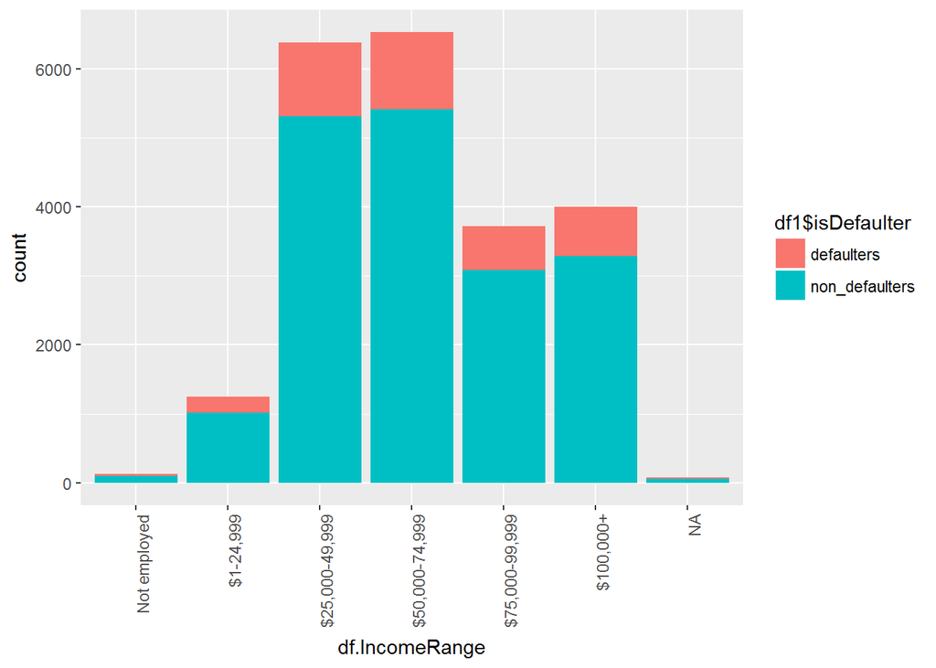

> There is no clear relation between number / % of defaulters and income range of borrowers

# Bivariate Analysis

### Did you observe any interesting relationships between the other features (not the main feature(s) of interest)?

Borrowers who are unemployed, or have income less than $25,000 - have higher median debt-income ratio, as compared to those having income above $25,000.

### What was the strongest relationship you found?

Strongest relationship was between borrowers’ stated monthly income and their monthly loan payments, where majority of borrowers with monthly income of up to $10,000 paid monthly loan payment of up to $1000 only.

# Multivariate Plots Section

### Analyzing relationship between income range and loan defaults

Relationship between income range and loans defaulted were analyzed, and categorized by prosper score.

#### Figure 17: Loan defaulters by income range and prosper score (1)

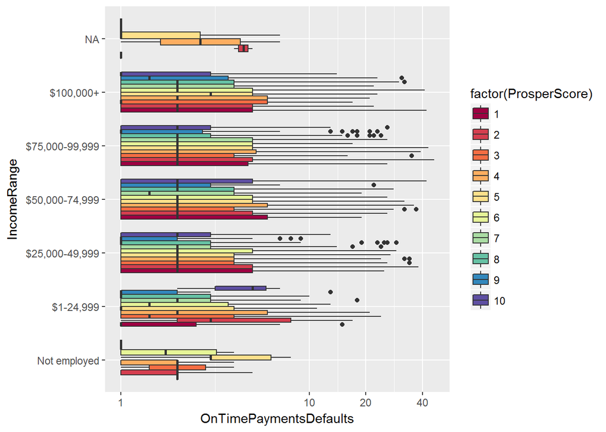

Relationship between income range and loans defaulted were analyzed, and categorized by prosper score through facets.

#### Figure 18: Loan defaulters by income range and prosper score (2)

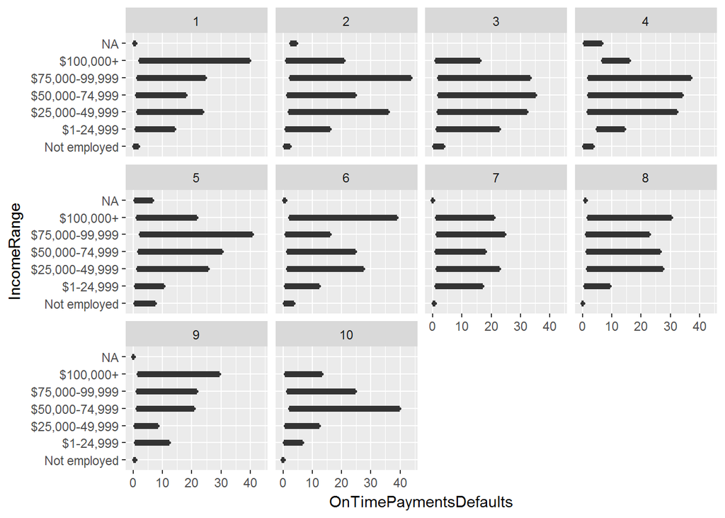

### Analyzing relationship between prior loans and loan defaults, and cetegorized by prosper scores

#### Figure 19: Loan defaulters by total loans and prosper score (1)

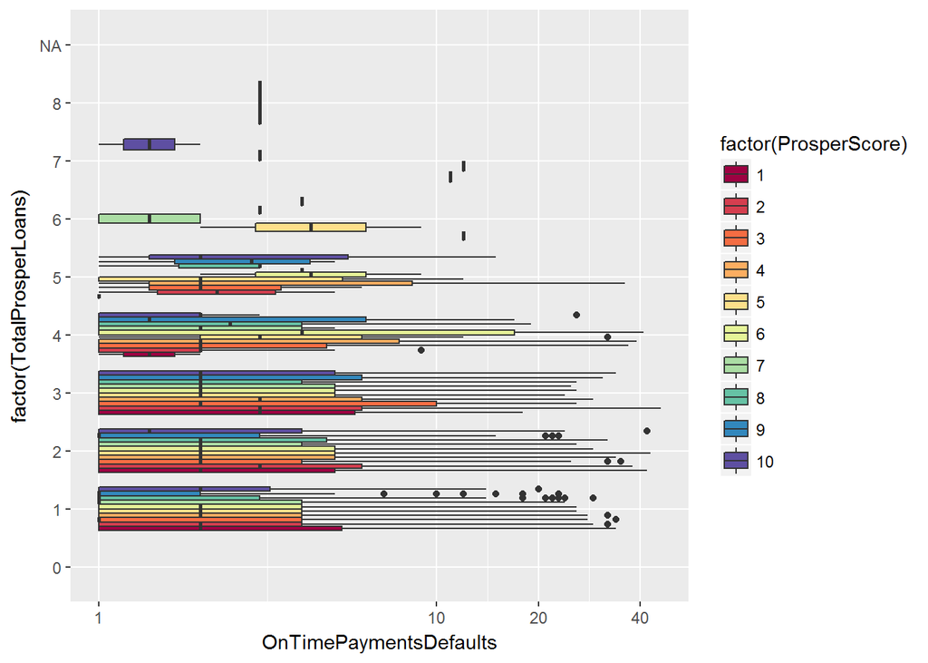

Analyzing the data through facets

#### Figure 20: Loan defaulters by total loans and prosper score (2)

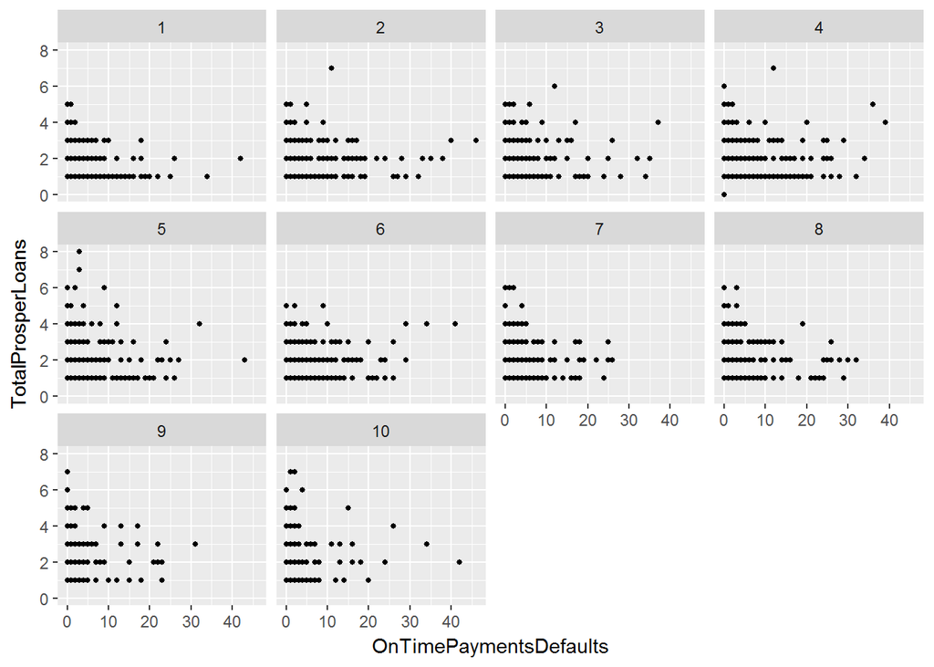

Correlation between TotalProsperLoans and OnTimePaymentsDefaults:

```
## [1] 0.1104858
```

> There are higher loan defaults with higher number of already existing prosper loans, with the correlation coefficient of 0.11.

### Analyzing relationship between Borrowers’ income, and the interest rate for loan

Plotting stated monthly income and borrower rate, and classifying it with term of loan

#### Figure 21: Relation between interest rate and stated monthly income of borrowers, by terms of loans, and regression line

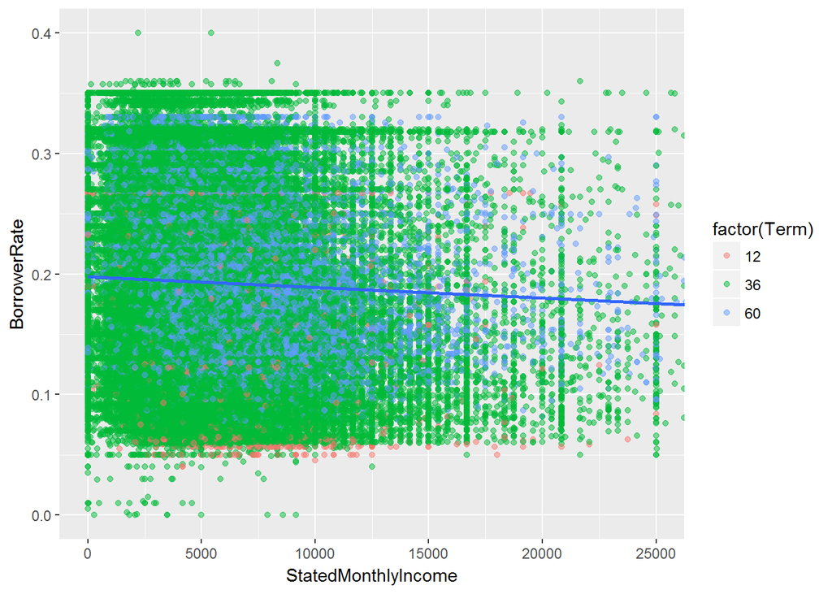

Correlation between StatedMonthlyIncome and BorrowerRate:

```
## [1] -0.0889818
```

Substituting stated monthly income with income range

#### Figure 22: Relation between interest rate and income range of borrowers, by terms of loans (1)

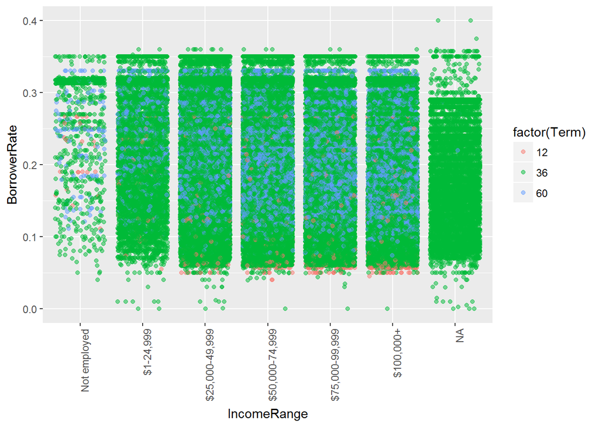

Analyzing the data through facets

#### Figure 23: Relation between interest rate and income range of borrowers, by terms of loans (2)

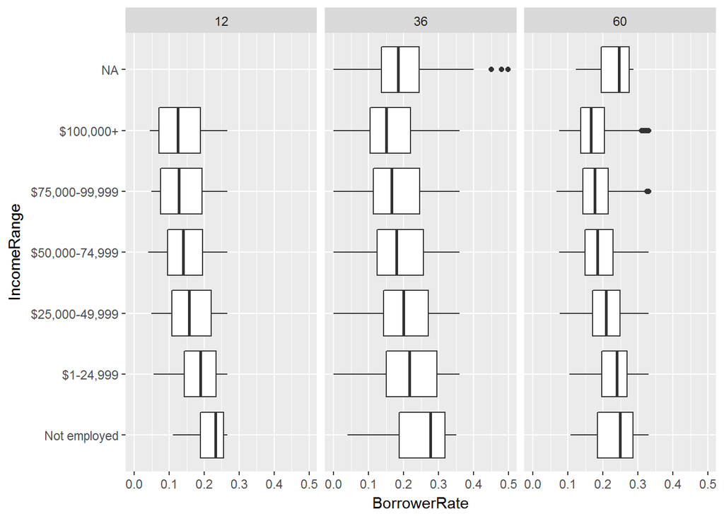

# Multivariate Analysis

### OPTIONAL: Did you create any models with your dataset? Discuss the strengths and limitations of your model.

NA

# Final Plots and Summary

### Plot One (Figure 24)

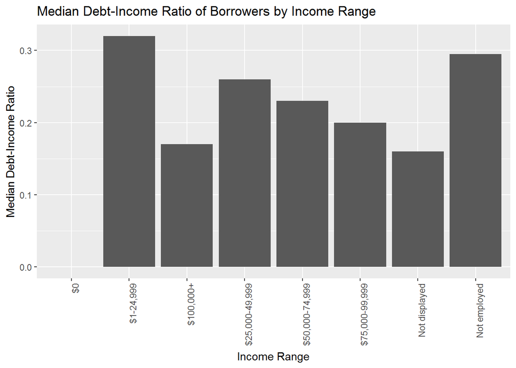

#### Statistical summary of median debt-income ratio

```
##    Min. 1st Qu.  Median    Mean 3rd Qu.    Max.    NA's
##  0.1600  0.1850  0.2300  0.2336  0.2775  0.3200       1
```

### Description One

The median debt-income ratio is higher for lower salary ranges ($1 - $50,000) than higher ranges ($50,000 and more). It shows that for an equal amount of loan, the debt-paying capacity of borrowers with annual income of more than $50,000 is better, as compared to those with lower income.

### Plot Two (Figure 25)

[figure not shown]

#### Statistical summary of loan borrowing rate

```
##    Min. 1st Qu.  Median    Mean 3rd Qu.    Max.
##  0.0000  0.1340  0.1840  0.1928  0.2500  0.4975
```

### Plot Three (Figure 26)

[figure not shown]

#### Statistical summary of loan payment defaults

```
##    Min. 1st Qu.  Median    Mean 3rd Qu.    Max.    NA's
##    0.00    0.00    0.00    0.72    0.00   46.00   64427
```

> The summary above minimum, 1st quartile and median as 0.00, as majority of the loans have 0 payment defaults (borrowers paid on time)

#### Calculating number of rows with loan defaults

```
## [1] "Rows with defaults:"
```

```
## [1] 3382
```

# Reflection

In this analysis, I have worked on the Loan Data from Prosper. The dataset had data on 113,937 loans with 81 variables, such as loan amount, borrower rate, current loan status, borrower income, borrower employment status, borrower credit history, and the latest payment information. I used the packages ggplot2 and dplyr for analysis, and knitr for knitting the RMD file to HTML file.

I started with univariate analysis, by understanding the data through different variables. Then, I selected some of the variables, which I believed could play a substantial direct or indirect role in whether a borrower pays his loans or defaults. Though some variables depicted relationship between them, others did not.

Finally, I performed multivariate analysis, by selecting borrowers’ payment defaults, income range, credit rating (prosper score), earlier loans on them, their monthly income and income range, loan rate of interest and loan term. Through the analysis, I was able to determine some key relationships between two or more variables.

I faced problems with consistency of data. Values across variables were missing, and I had to perform data wrangling to make the data useful for analysis. Also, the definitions of some of the variables were not clear, and it would have been better if the definitions were more descriptive.

Further, I would like to mention that the relation and correlation among different variables should not be considered as causation. There should be further analysis such as linear regression to study causes and effects in detail.